# SOST20131/30031 — Assessment Part 2

University ID: 11617469

2026-05-19

# 1 Question 1: Employee Performance Study

## 1.1 Research Question

**Objective:** A multiple regression model comprising a response variable (Y) and explanatory variables (Xi) that explain behaviour of, or variability in Y.

$$Y = \beta_0 + \beta_1 X_1 + \beta_2 X_2
+ \ldots + \beta_k X_k + \varepsilon$$

For general k explanatory variables, where $\varepsilon$ is the error term.

> **“How do test scores and background characteristics explain variation in employee sales performance?”**

## 1.2 Data Description and Exploratory Analysis

```r
Q1_Data <- read.csv("Data/Employee_Performance.csv")
Q2_Data <- read.csv("Data/Diabetes_Data.csv")
```

```r
# Converting categorical variables to factors for EDA
Q1_Data$Type <- factor(Q1_Data$Type,
                        levels = c(0, 1),
                        labels = c("Science", "Business"))

Q1_Data$Level <- factor(Q1_Data$Level,
                         levels = c(1, 2, 3),
                         labels = c("Degree", "Masters", "Doctorate"))

Q1_Data$Expertise <- factor(Q1_Data$Expertise,
                              levels = c(1, 2, 3, 4),
                              labels = c("Logistics", "Promotion", "Sales", "Strategy"))
```

### 1.2.1 Response Variable — Sales Performance

```r
# Summary statistics for response and measured variables
data_measured <- Q1_Data[, c("Sales_Perf", "Creativity", "Mechanical", "Abstract", "Maths")]

summary_stats <- data.frame(
  Mean   = apply(data_measured, 2, mean),
  Median = apply(data_measured, 2, median),
  SD     = apply(data_measured, 2, sd),
  Min    = apply(data_measured, 2, min),
  Max    = apply(data_measured, 2, max)
)
round(summary_stats, 2)
```

```
##              Mean Median    SD  Min   Max
## Sales_Perf 106.27  105.4  9.85 89.8 122.3
## Creativity  10.98   10.0  3.91  1.0  18.0
## Mechanical  14.21   14.5  3.53  5.0  20.0
## Abstract    11.35   11.0  1.47  8.0  15.0
## Maths       29.12   30.5 10.50  9.0  51.0
```

*Table 1: Summary statistics for response and measured variables.*

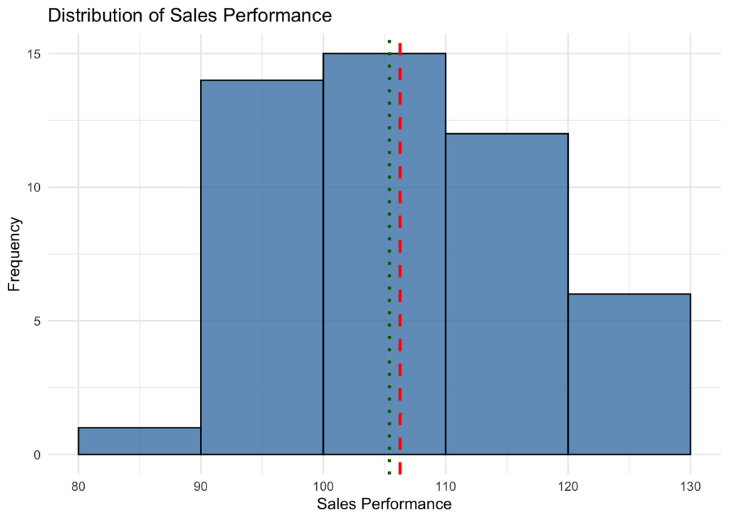

Figure 1: Distribution of sales performance score (red = mean, green = median)

```r
ggplot(Q1_Data, aes(x = Sales_Perf)) +
  geom_histogram(
    breaks   = seq(80, 130, by = 10),
    fill     = "steelblue",
    color    = "black",
    alpha    = 0.8
  ) +
  geom_vline(xintercept = mean(Q1_Data$Sales_Perf),
             color = "red", linetype = "dashed", linewidth = 1) +
  geom_vline(xintercept = median(Q1_Data$Sales_Perf),
             color = "darkgreen", linetype = "dotted", linewidth = 1) +
  scale_x_continuous(breaks = seq(80, 130, by = 10), limits = c(80, 130)) +
  labs(title = "Distribution of Sales Performance",
       x = "Sales Performance", y = "Frequency") +
  theme_minimal()
```

### 1.2.2 Explanatory Variables

The explanatory variables fall into two groups:

**1. Measured** — test scores in Creativity, Mechanical, Abstract, and Maths.

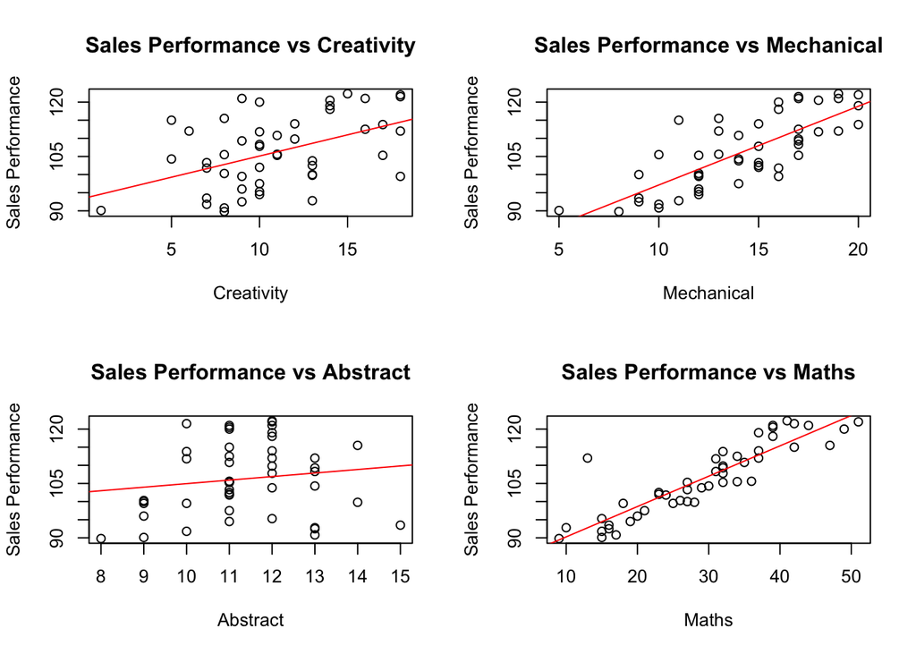

Figure 2: Scatter plots depicting the relationship between sales performance and test scores

```r
par(mfrow = c(2, 2))

plot(Q1_Data$Creativity, Q1_Data$Sales_Perf,
     xlab = "Creativity", ylab = "Sales Performance",
     main = "Sales Performance vs Creativity")
abline(lm(Sales_Perf ~ Creativity, data = Q1_Data), col = "red")

plot(Q1_Data$Mechanical, Q1_Data$Sales_Perf,
     xlab = "Mechanical", ylab = "Sales Performance",
     main = "Sales Performance vs Mechanical")
abline(lm(Sales_Perf ~ Mechanical, data = Q1_Data), col = "red")

plot(Q1_Data$Abstract, Q1_Data$Sales_Perf,
     xlab = "Abstract", ylab = "Sales Performance",
     main = "Sales Performance vs Abstract")
abline(lm(Sales_Perf ~ Abstract, data = Q1_Data), col = "red")

plot(Q1_Data$Maths, Q1_Data$Sales_Perf,
     xlab = "Maths", ylab = "Sales Performance",
     main = "Sales Performance vs Maths")
abline(lm(Sales_Perf ~ Maths, data = Q1_Data), col = "red")
```

```r
par(mfrow = c(1, 1))
```

Measured test scores show approximately symmetric distributions with no strong skewness, as evidenced by the close mean and median values in Table 1. Scatterplots (Figure 2) indicate positive relationships with `Sales_Perf`, strongest for Maths (r = 0.89), followed by Mechanical, and weaker for Creativity and Abstract. This aligns with expectations in a business analytics context where higher maths scores would be associated with higher sales performance.

**2. Attribute** — categorical background variables:

- **Type** (background): Science, Business
- **Level** (education): Degree, Masters, Doctorate
- **Expertise** (area): Logistics, Promotion, Sales, Strategy

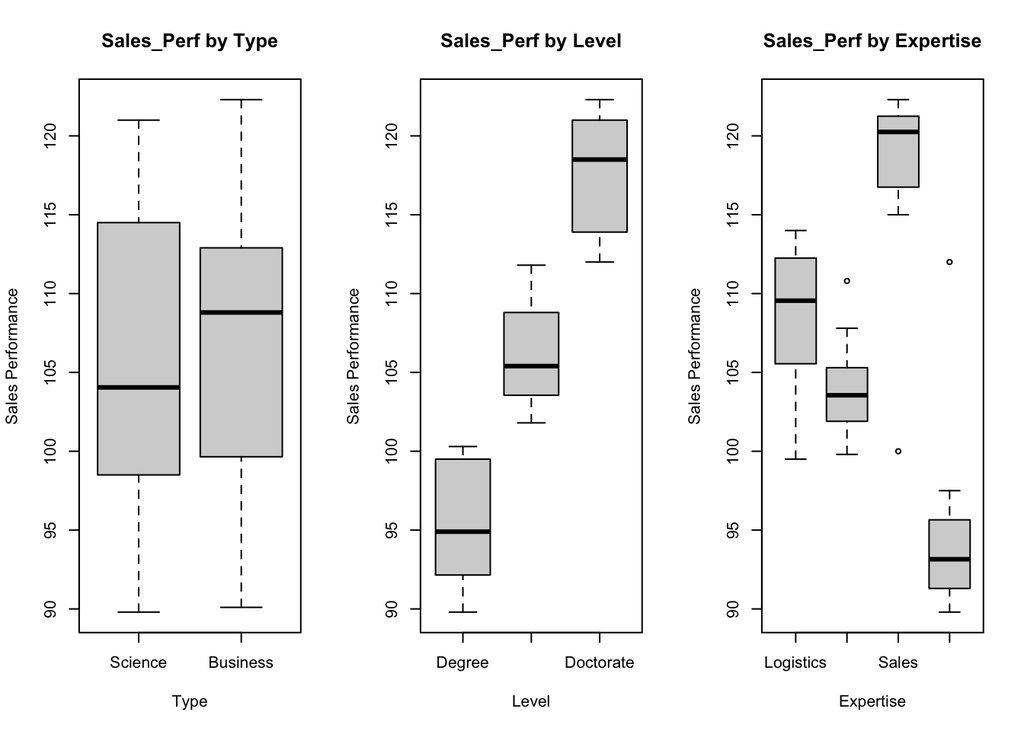

Figure 3: Box plots showing differences in Sales Performance across categorical variables

```r
par(mfrow = c(1, 3))

boxplot(Sales_Perf ~ Type, data = Q1_Data,
        main = "Sales_Perf by Type",
        xlab = "Type", ylab = "Sales Performance")

boxplot(Sales_Perf ~ Level, data = Q1_Data,
        main = "Sales_Perf by Level",
        xlab = "Level", ylab = "Sales Performance")

boxplot(Sales_Perf ~ Expertise, data = Q1_Data,
        main = "Sales_Perf by Expertise",
        xlab = "Expertise", ylab = "Sales Performance")
```

```r
par(mfrow = c(1, 1))
```

Boxplots (Figure 3) show minimal variation in background type, with substantial overlap in interquartile ranges. There is a clear upward trend across education levels (Degree → Masters → Doctorate) and substantial variation by expertise, with those specialising in Sales exhibiting the highest median `Sales_Perf`.

### 1.2.3 Examining Bivariate Relationships

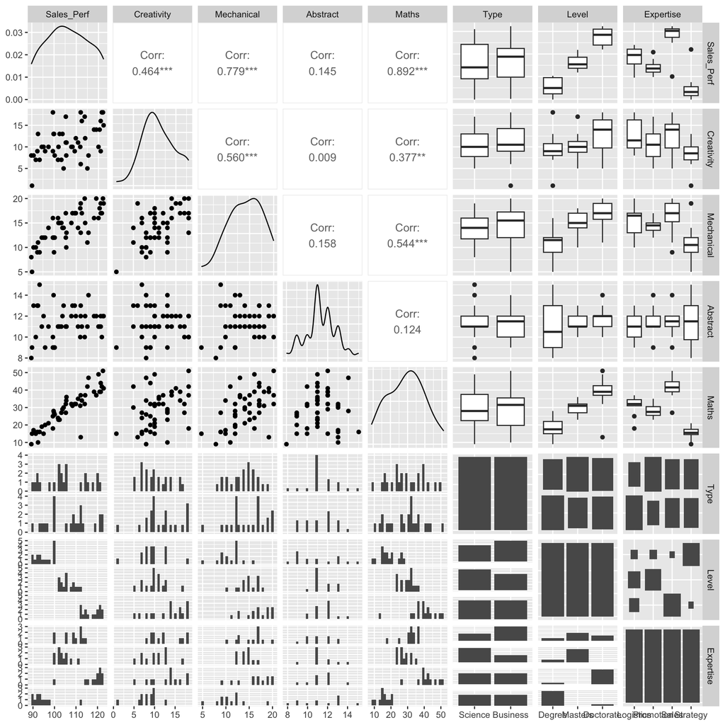

Figure 4: Exploratory plots examining relationships among all variables

```r
GGally::ggpairs(
  Q1_Data,
  columns = c("Sales_Perf", "Creativity", "Mechanical",
              "Abstract", "Maths", "Type", "Level", "Expertise")
)
```

```r
# Checking for potential multicollinearity between Mechanical and Maths
model_b <- lm(Mechanical ~ Maths, data = Q1_Data)
summary(model_b)
```

```
##
## Call:
## lm(formula = Mechanical ~ Maths, data = Q1_Data)
##
## Residuals:
##     Min      1Q  Median      3Q     Max
## -6.6256 -1.9941  0.0289  2.0560  7.7401
##
## Coefficients:
##             Estimate Std. Error t value Pr(>|t|)
## (Intercept)   8.8829     1.2864   6.905 1.26e-08 ***
## Maths         0.1829     0.0416   4.395 6.47e-05 ***
## ---
## Signif. codes:  0 '***' 0.001 '**' 0.01 '*' 0.05 '.' 0.1 ' ' 1
##
## Residual standard error: 2.995 on 46 degrees of freedom
## Multiple R-squared:  0.2958, Adjusted R-squared:  0.2805
## F-statistic: 19.32 on 1 and 46 DF,  p-value: 6.468e-05
```

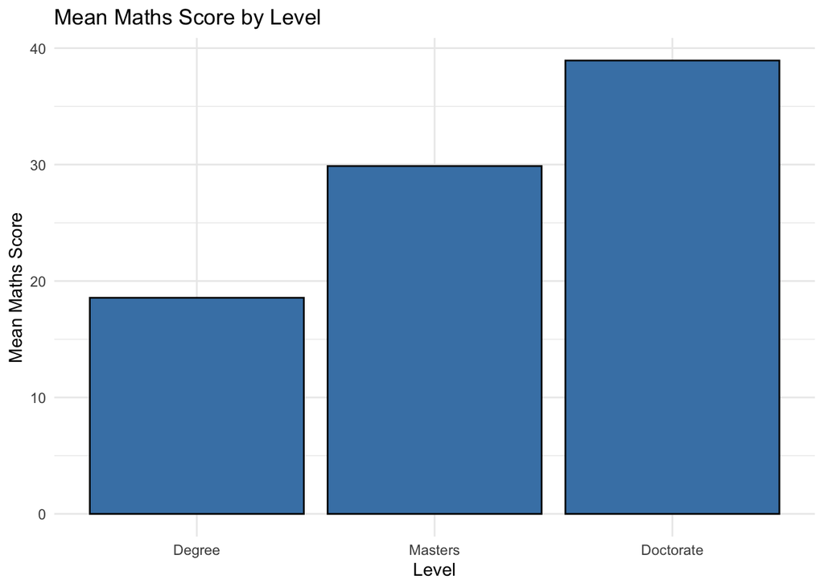

Mean Maths score by education level

```r
ggplot(Q1_Data, aes(x = Level, y = Maths)) +
  stat_summary(fun = mean, geom = "bar", col = "black", fill = "steelblue") +
  labs(title = "Mean Maths Score by Level",
       x = "Level", y = "Mean Maths Score") +
  theme_minimal()
```

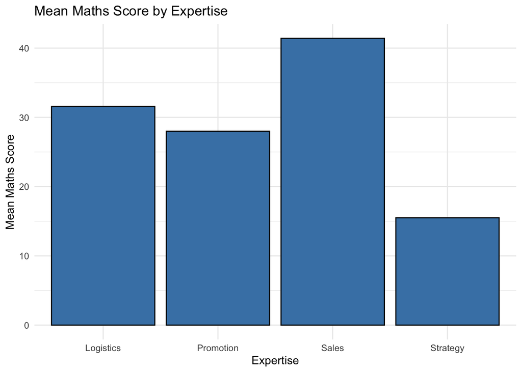

Mean Maths score by expertise area

```r
ggplot(Q1_Data, aes(x = Expertise, y = Maths)) +
  stat_summary(fun = mean, geom = "bar", col = "black", fill = "steelblue") +
  labs(title = "Mean Maths Score by Expertise",
       x = "Expertise", y = "Mean Maths Score") +
  theme_minimal()
```

Certain test scores (e.g., Mechanical with Creativity and Maths) show moderate positive correlations, suggesting potential multicollinearity when highly correlated predictors are entered together into the regression model. Additionally, Maths scores vary significantly across education level and expertise (Figure 4). This is formally assessed in the Model Selection and Refinement section.

## 1.3 Initial Model Specification

### 1.3.1 The Model

$$\text{Sales\_Perf} = \beta_0 + \beta_1
\cdot \text{Creativity} + \beta_2 \cdot \text{Mechanical} + \beta_3
\cdot \text{Abstract} + \beta_4 \cdot \text{Maths} + \beta_5 \cdot
\text{Type} + \beta_6 \cdot \text{Level} + \beta_7 \cdot
\text{Expertise} + \varepsilon$$

It is important to consider all independent variables in the initial model to reduce the risk of omitted-variable bias, then move towards a simpler but effective model.

```r
# Initial model with all candidate predictors
# R automatically encodes categorical predictors as dummy variables
# using a reference category
model_1 <- lm(Sales_Perf ~ ., data = Q1_Data)
summary(model_1)
```

```
##
## Call:
## lm(formula = Sales_Perf ~ ., data = Q1_Data)
##
## Residuals:
##     Min      1Q  Median      3Q     Max
## -2.7319 -0.7462 -0.0842  0.9410  3.3368
##
## Coefficients:
##                    Estimate Std. Error t value Pr(>|t|)
## (Intercept)        83.65770    2.54864  32.824  < 2e-16 ***
## Creativity         -0.06546    0.07921  -0.826  0.41387
## Mechanical          0.69435    0.11276   6.158 3.84e-07 ***
## Abstract           -0.03181    0.16660  -0.191  0.84961
## Maths               0.26970    0.05717   4.717 3.37e-05 ***
## TypeBusiness        1.61522    0.48689   3.317  0.00205 **
## LevelMasters        4.68240    1.02720   4.558 5.47e-05 ***
## LevelDoctorate     10.02595    1.17987   8.498 3.19e-10 ***
## ExpertisePromotion -0.58234    0.73158  -0.796  0.43110
## ExpertiseSales      3.07774    0.90468   3.402  0.00162 **
## ExpertiseStrategy  -1.44663    1.17893  -1.227  0.22755
## ---
## Signif. codes:  0 '***' 0.001 '**' 0.01 '*' 0.05 '.' 0.1 ' ' 1
##
## Residual standard error: 1.548 on 37 degrees of freedom
## Multiple R-squared:  0.9806, Adjusted R-squared:  0.9753
## F-statistic: 186.7 on 10 and 37 DF,  p-value: < 2.2e-16
```

```r
# Critical F-value at alpha = 0.05 with 10 and 37 df
qf(0.95, 10, 37)
```

```
## [1] 2.098239
```

### 1.3.2 Dummy Variables

Categorical variables are encoded using dummy variables, with a reference level (coded 0) against which all other levels are compared.

- **Type** reference: Science
- **Level** reference: Degree
- **Expertise** reference: Logistics

The negative coefficients for some variables (Creativity, Abstract, ExpertisePromotion, ExpertiseStrategy) reflect overlapping explanatory power once other variables are controlled for, rather than a negative theoretical effect.

## 1.4 Model Selection and Refinement

### 1.4.1 Overall Model Fit

The initial model shows excellent fit (Adjusted R² = 97.53%), meaning it explains the vast majority of variability in `Sales_Perf`. Using the F-test, F<sub>crit</sub> = 2.098 < F<sub>calc</sub> = 186.7, confirming this is a valid model. The objective now is to identify the minimal adequate model.

### 1.4.2 Removing Non-Significant Predictors

```r
# Step 1: Remove Abstract (p = 0.85, large p-value, weak scatter relationship)
model_2 <- lm(Sales_Perf ~ Creativity + Mechanical + Maths + Type + Expertise + Level,
              data = Q1_Data)
summary(model_2)
```

```
##
## Call:
## lm(formula = Sales_Perf ~ Creativity + Mechanical + Maths + Type +
##     Expertise + Level, data = Q1_Data)
##
## Residuals:
##     Min      1Q  Median      3Q     Max
## -2.7198 -0.7457 -0.0734  0.9616  3.3653
##
## Coefficients:
##                    Estimate Std. Error t value Pr(>|t|)
## (Intercept)        83.41804    2.18987  38.093  < 2e-16 ***
## Creativity         -0.06585    0.07817  -0.842  0.40486
## Mechanical          0.69252    0.11092   6.244 2.64e-07 ***
## Maths               0.26754    0.05533   4.835 2.22e-05 ***
## TypeBusiness        1.62037    0.47994   3.376  0.00171 **
## ExpertisePromotion -0.59802    0.71768  -0.833  0.40991
## ExpertiseSales      3.09324    0.88953   3.477  0.00128 **
## ExpertiseStrategy  -1.51461    1.10955  -1.365  0.18026
## LevelMasters        4.65938    1.00708   4.627 4.23e-05 ***
## LevelDoctorate     10.00660    1.16051   8.623 1.77e-10 ***
## ---
## Signif. codes:  0 '***' 0.001 '**' 0.01 '*' 0.05 '.' 0.1 ' ' 1
##
## Residual standard error: 1.528 on 38 degrees of freedom
## Multiple R-squared:  0.9805, Adjusted R-squared:  0.9759
## F-statistic: 212.8 on 9 and 38 DF,  p-value: < 2.2e-16
```

The change in Adjusted R² is marginal (<1%) and coefficient estimates remain stable, so Abstract is safely removed.

```r
# Step 2: Remove Creativity (least influential after Abstract)
model_3 <- lm(Sales_Perf ~ Mechanical + Maths + Type + Expertise + Level,
              data = Q1_Data)
summary(model_3)
```

```
##
## Call:
## lm(formula = Sales_Perf ~ Mechanical + Maths + Type + Expertise +
##     Level, data = Q1_Data)
##
## Residuals:
##     Min      1Q  Median      3Q     Max
## -2.6409 -0.8593  0.0555  0.9615  3.2718
##
## Coefficients:
##                    Estimate Std. Error t value Pr(>|t|)
## (Intercept)        83.02821    2.13243  38.936  < 2e-16 ***
## Mechanical          0.65100    0.09899   6.576 8.22e-08 ***
## Maths               0.26784    0.05513   4.859 1.95e-05 ***
## TypeBusiness        1.60600    0.47785   3.361 0.001749 **
## ExpertisePromotion -0.56683    0.71405  -0.794 0.432107
## ExpertiseSales      3.16870    0.88171   3.594 0.000903 ***
## ExpertiseStrategy  -1.21939    1.04882  -1.163 0.252043
## LevelMasters        4.97227    0.93259   5.332 4.38e-06 ***
## LevelDoctorate     10.15796    1.14223   8.893 6.36e-11 ***
## ---
## Signif. codes:  0 '***' 0.001 '**' 0.01 '*' 0.05 '.' 0.1 ' ' 1
##
## Residual standard error: 1.522 on 39 degrees of freedom
## Multiple R-squared:  0.9802, Adjusted R-squared:  0.9761
## F-statistic: 241.1 on 8 and 39 DF,  p-value: < 2.2e-16
```

```r
round(summary(model_3)$coefficients, 2)
```

```
##                    Estimate Std. Error t value Pr(>|t|)
## (Intercept)           83.03       2.13   38.94     0.00
## Mechanical             0.65       0.10    6.58     0.00
## Maths                  0.27       0.06    4.86     0.00
## TypeBusiness           1.61       0.48    3.36     0.00
## ExpertisePromotion    -0.57       0.71   -0.79     0.43
## ExpertiseSales         3.17       0.88    3.59     0.00
## ExpertiseStrategy     -1.22       1.05   -1.16     0.25
## LevelMasters           4.97       0.93    5.33     0.00
## LevelDoctorate        10.16       1.14    8.89     0.00
```

Again, the change in Adjusted R² is negligible and estimates remain stable.

```r
# Step 3: Test whether Type contributes significantly
model_a <- lm(Sales_Perf ~ Mechanical + Maths + Expertise + Level, data = Q1_Data)
summary(model_a)
```

```
##
## Call:
## lm(formula = Sales_Perf ~ Mechanical + Maths + Expertise + Level,
##     data = Q1_Data)
##
## Residuals:
##     Min      1Q  Median      3Q     Max
## -3.0007 -1.2666 -0.0693  0.9285  4.3562
##
## Coefficients:
##                    Estimate Std. Error t value Pr(>|t|)
## (Intercept)        82.71471    2.38888  34.625  < 2e-16 ***
## Mechanical          0.74918    0.10606   7.064 1.53e-08 ***
## Maths               0.28559    0.06153   4.641 3.68e-05 ***
## ExpertisePromotion -1.04670    0.78452  -1.334 0.189691
## ExpertiseSales      2.91609    0.98509   2.960 0.005148 **
## ExpertiseStrategy  -1.36228    1.17511  -1.159 0.253215
## LevelMasters        4.29172    1.02080   4.204 0.000143 ***
## LevelDoctorate      9.10945    1.23213   7.393 5.35e-09 ***
## ---
## Signif. codes:  0 '***' 0.001 '**' 0.01 '*' 0.05 '.' 0.1 ' ' 1
##
## Residual standard error: 1.707 on 40 degrees of freedom
## Multiple R-squared:  0.9744, Adjusted R-squared:   0.97
## F-statistic: 217.9 on 7 and 40 DF,  p-value: < 2.2e-16
```

```r
# Using anova() to compare models with and without Type
anova(model_3, model_a)
```

```
## Analysis of Variance Table
##
## Model 1: Sales_Perf ~ Mechanical + Maths + Type + Expertise + Level
## Model 2: Sales_Perf ~ Mechanical + Maths + Expertise + Level
##   Res.Df     RSS Df Sum of Sq      F   Pr(>F)
## 1     39  90.396
## 2     40 116.577 -1   -26.181 11.296 0.001749 **
## ---
## Signif. codes:  0 '***' 0.001 '**' 0.01 '*' 0.05 '.' 0.1 ' ' 1
```

The model comparison indicates that background Type contributes significantly to the response variable (F = 11.30, p < 0.01) and is retained. Education Level and Expertise are also retained as they contribute meaningfully when assessed jointly across all levels.

### 1.4.3 Multicollinearity

```r
# Variance Inflation Factors for the refined model
car::vif(model_3)
```

```
##                 GVIF Df GVIF^(1/(2*Df))
## Mechanical  2.477256  1        1.573930
## Maths       6.795553  1        2.606828
## Type        1.182169  1        1.087276
## Expertise  12.966698  3        1.532751
## Level      10.548729  2        1.802188
```

## 1.5 Final Model and Interpretation

### 1.5.1 Final Regression Model

$$\text{Sales\_Perf} = 83.03 + 0.65 \cdot
\text{Mechanical} + 0.27 \cdot \text{Maths} + 1.61 \cdot
\text{TypeBusiness} + 4.97 \cdot \text{LevelMasters} + 10.16 \cdot
\text{LevelDoctorate} + 3.17 \cdot \text{ExpertiseSales} - 0.57 \cdot
\text{ExpertisePromotion} - 1.22 \cdot
\text{ExpertiseStrategy}$$

Maths and Mechanical scores show positive associations, with Mechanical having a larger marginal effect. A Business background has a modest positive effect of 1.61 points on average compared to Science. Education level exhibits increasing returns relative to the Degree baseline. Relative to Logistics, Sales expertise is associated with higher performance, while Promotion and Strategy are slightly lower. The signs and magnitudes of coefficients are consistent with the skills and context required for sales performance.

### 1.5.2 Model Diagnostics

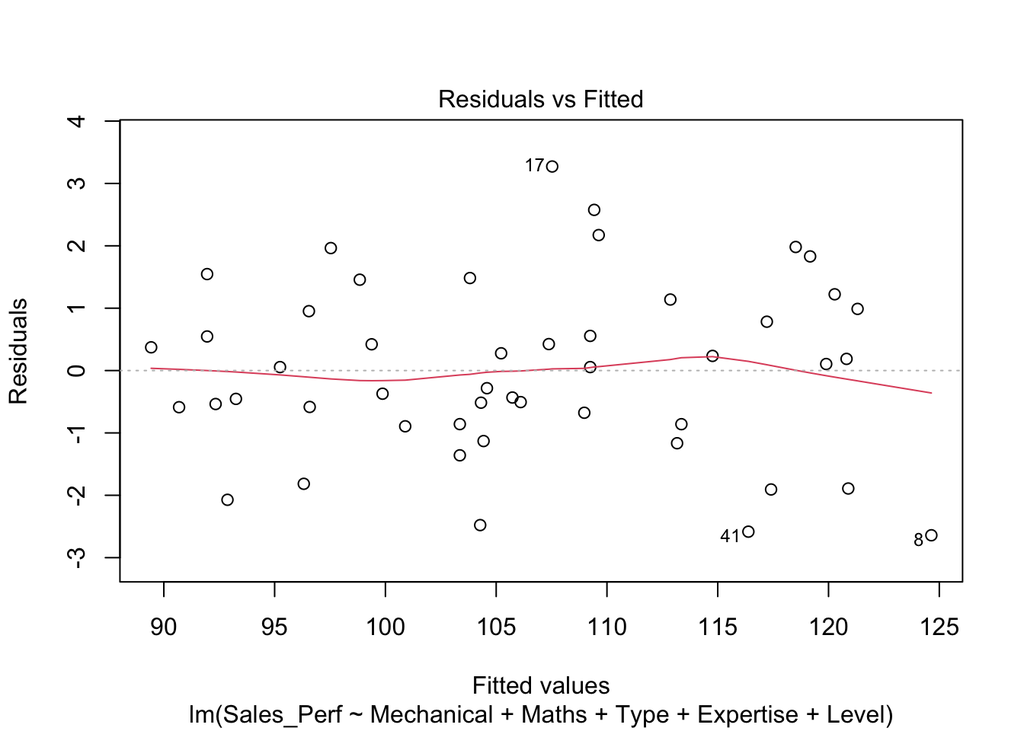

Figure 5 & 6: Residuals vs Fitted Values and Normality of Residuals

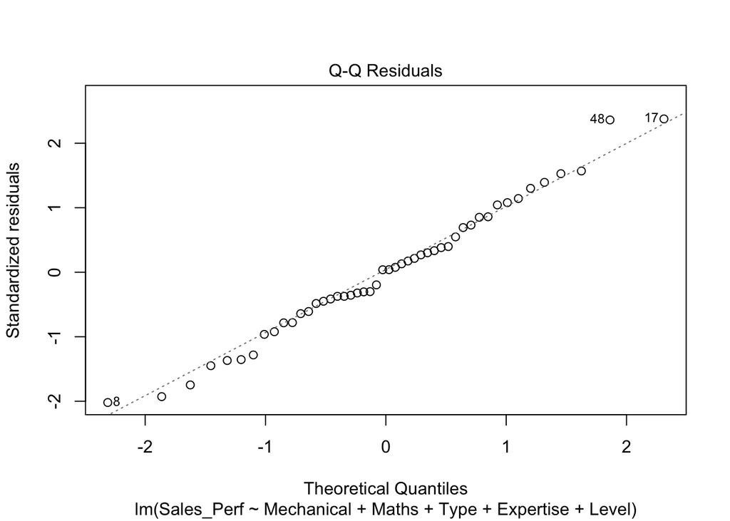

Figure 5 & 6: Residuals vs Fitted Values and Normality of Residuals

```r
# Base R diagnostic plots
plot(model_3, which = c(1, 2))
```

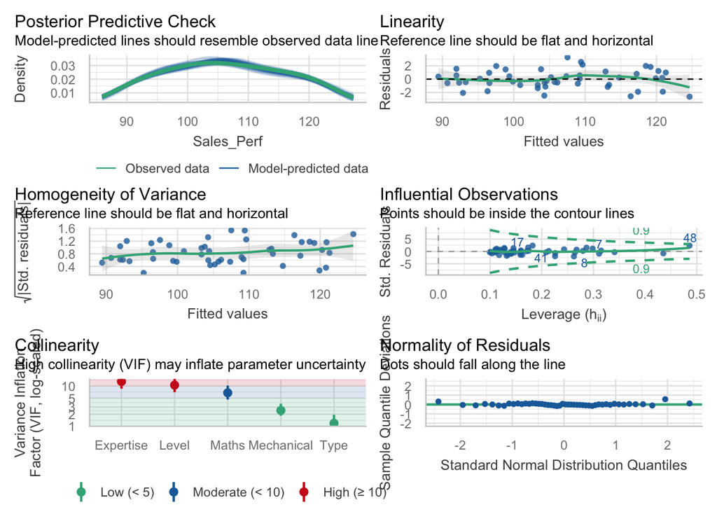

Extended model diagnostics

```r
# Extended performance-package diagnostics
library(performance)
check_model(model_3)
```

Points in the residuals vs fitted plot (Figure 5) are randomly spread around 0 with no clear pattern, supporting the linearity assumption. The Q-Q plot (Figure 6) confirms that residuals are approximately normally distributed.

## 1.6 Prediction and Quality

```r
# Prediction for a specified employee profile
values <- data.frame(
  Mechanical = 18,
  Maths      = 60,
  Type       = factor("Science",   levels = levels(Q1_Data$Type)),
  Level      = factor("Doctorate", levels = levels(Q1_Data$Level)),
  Expertise  = factor("Promotion", levels = levels(Q1_Data$Expertise))
)

predval <- predict(model_3, newdata = values)
round(predval, 2)
```

```
##      1
## 120.41
```

The predicted `Sales_Perf` for this profile is **120.41**, which is a reasonable prediction given the model’s high Adjusted R² of 97.61%. However, it should be interpreted with caution for three reasons:

1. The small sample size (n = 48) means estimates carry more uncertainty.
2. A Maths score of 60 lies outside the observed sample range (max = 51), making this prediction less reliable.
3. The residual standard error of 1.52 means individual-level predictions may vary due to unexplained variability.

### 1.6.1 Conclusion

This analysis identified a multiple regression model explaining 97.61% of variance in sales performance. The final model retained five key predictors: Mechanical and Maths test scores, educational background, education level, and expertise area. It would benefit from a larger sample and validation on independent data to confirm its predictive performance.

# 2 Question 2: Diabetes

## 2.1 Research Question

**Objective:** To model the probability that an individual has diabetes or prediabetes based on a set of health indicators using a logistic regression model.

$$\text{logit}(p) =
\log\left(\frac{p}{1-p}\right) = \beta_0 + \beta_1 X_1 + \beta_2 X_2 +
\ldots + \beta_k X_k$$

Where $p = P(\text{Diabetes} = 1)$.

- **Response variable:** 0 = no diabetes; 1 = diabetes or prediabetes
- **Explanatory variables:** HighBP, HighChol, BMI, Smoker, Fruits, Age

> **“How do various health indicators affect the probability of an individual having diabetes or prediabetes?”**

## 2.2 Data Description and Exploration

```r
# Converting binary variables to factors
Q2_Data$HighBP   <- factor(Q2_Data$HighBP)
Q2_Data$HighChol <- factor(Q2_Data$HighChol)
Q2_Data$Smoker   <- factor(Q2_Data$Smoker)
Q2_Data$Fruits   <- factor(Q2_Data$Fruits)
Q2_Data$Diabetes <- factor(Q2_Data$Diabetes)
```

### 2.2.1 Binary Variables

```r
# Counts and proportions for all binary variables
lapply(
  Q2_Data[c("HighBP", "HighChol", "Smoker", "Fruits", "Diabetes")],
  function(x) {
    cbind(
      Count      = table(x),
      Proportion = round(prop.table(table(x)), 3)
    )
  }
)
```

```
## $HighBP
##   Count Proportion
## 0    60        0.4
## 1    90        0.6
##
## $HighChol
##   Count Proportion
## 0    68      0.453
## 1    82      0.547
##
## $Smoker
##   Count Proportion
## 0    81       0.54
## 1    69       0.46
##
## $Fruits
##   Count Proportion
## 0    59      0.393
## 1    91      0.607
##
## $Diabetes
##   Count Proportion
## 0    74      0.493
## 1    76      0.507
```

*Table 5: Counts and proportions for binary variables.*

Overall, binary variables are reasonably balanced, with slightly higher proportions of individuals reporting high blood pressure (0.60) and fruit consumption (0.61).

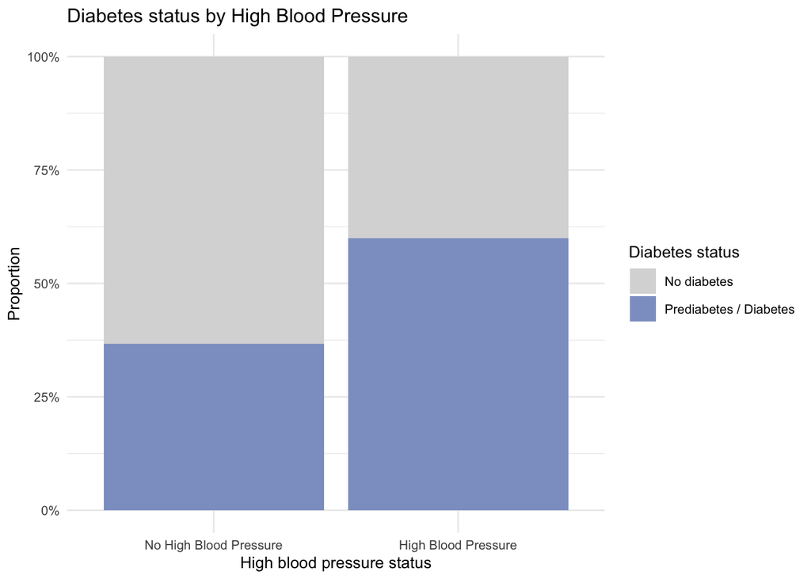

Figure 8: Diabetes status by blood pressure

```r
ggplot(Q2_Data, aes(x = factor(HighBP), fill = factor(Diabetes))) +
  geom_bar(position = "fill") +
  scale_y_continuous(labels = scales::percent) +
  scale_fill_manual(
    values = c("0" = "#D9D9D9", "1" = "#8DA0CB"),
    labels = c("No diabetes", "Prediabetes / Diabetes")
  ) +
  labs(x = "High blood pressure status", y = "Proportion",
       fill = "Diabetes status",
       title = "Diabetes status by High Blood Pressure") +
  scale_x_discrete(labels = c("0" = "No High Blood Pressure",
                               "1" = "High Blood Pressure")) +
  theme_minimal(base_size = 10)
```

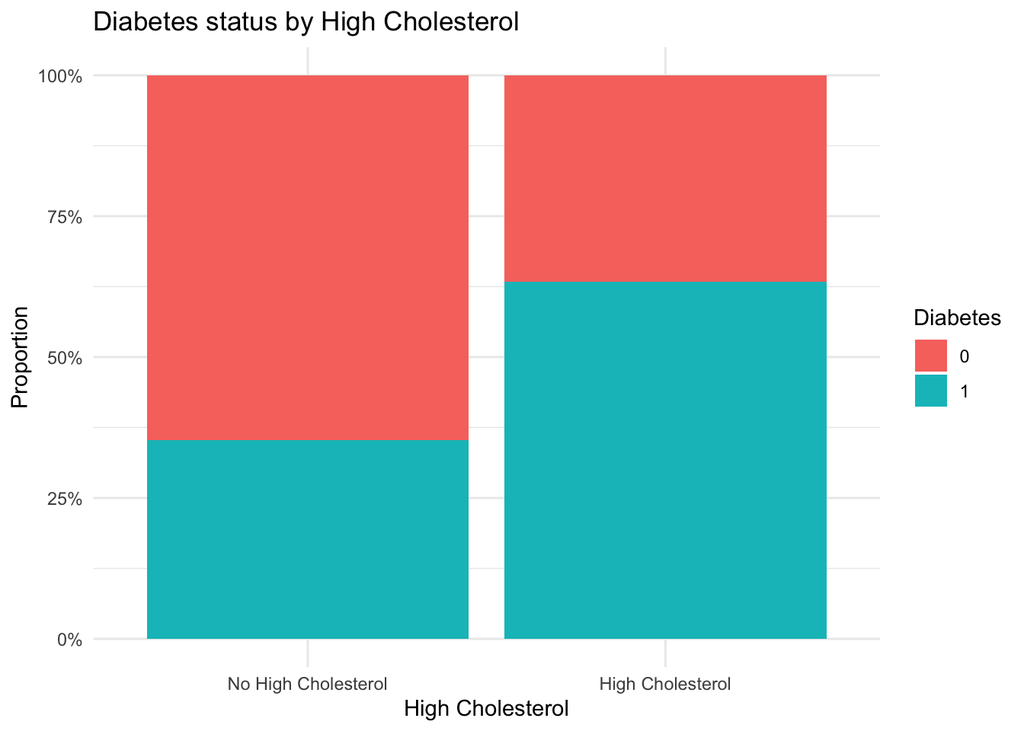

Figure 10: Diabetes status by cholesterol

```r
ggplot(Q2_Data, aes(x = factor(HighChol), fill = Diabetes)) +
  geom_bar(position = "fill") +
  scale_y_continuous(labels = scales::percent) +
  labs(x = "High Cholesterol", y = "Proportion",
       fill = "Diabetes",
       title = "Diabetes status by High Cholesterol") +
  scale_x_discrete(labels = c("0" = "No High Cholesterol",
                               "1" = "High Cholesterol")) +
  theme_minimal()
```

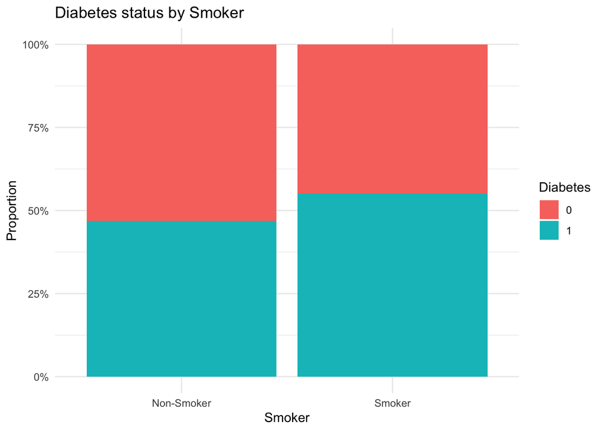

Figure 7: Diabetes status by smoker

```r
ggplot(Q2_Data, aes(x = factor(Smoker), fill = Diabetes)) +
  geom_bar(position = "fill") +
  scale_y_continuous(labels = scales::percent) +
  labs(x = "Smoker", y = "Proportion",
       fill = "Diabetes",
       title = "Diabetes status by Smoker") +
  scale_x_discrete(labels = c("0" = "Non-Smoker", "1" = "Smoker")) +
  theme_minimal()
```

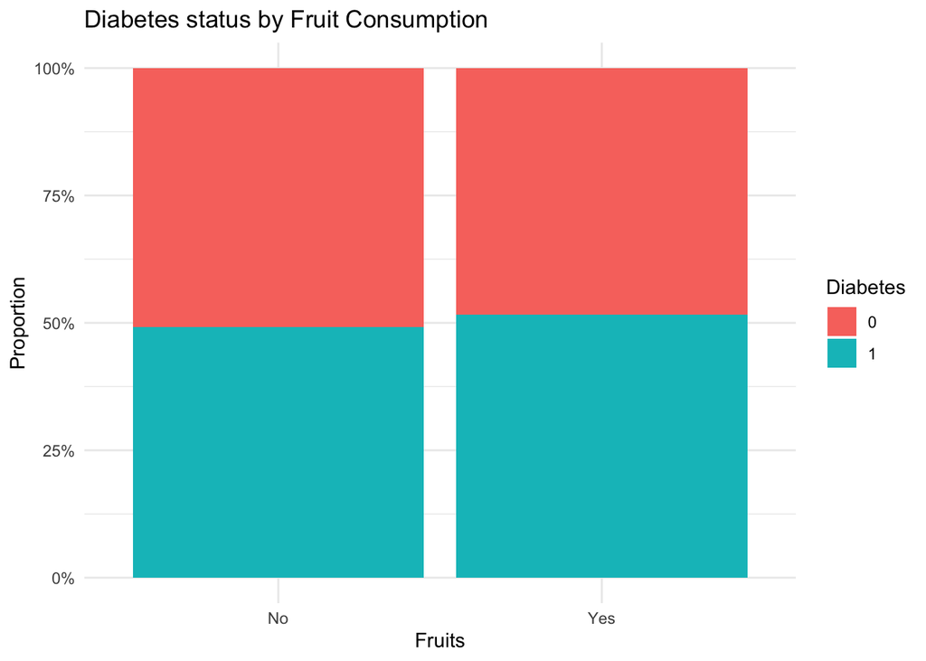

Figure 9: Diabetes status by fruit consumption

```r
ggplot(Q2_Data, aes(x = factor(Fruits), fill = Diabetes)) +
  geom_bar(position = "fill") +
  scale_y_continuous(labels = scales::percent) +
  labs(x = "Fruits", y = "Proportion",
       fill = "Diabetes",
       title = "Diabetes status by Fruit Consumption") +
  scale_x_discrete(labels = c("0" = "No", "1" = "Yes")) +
  theme_minimal()
```

Higher proportions of diabetes or prediabetes are observed among individuals with high blood pressure and high cholesterol (Figures 7–10).

### 2.2.2 Measured Variables

```r
# Summary statistics for BMI and Age by diabetes status
Q2_Data %>%
  group_by(Diabetes) %>%
  summarise(
    mean_BMI   = mean(BMI),   median_BMI = median(BMI),
    sd_BMI     = sd(BMI),     min_BMI    = min(BMI),    max_BMI = max(BMI),
    mean_Age   = mean(Age),   median_Age = median(Age),
    sd_Age     = sd(Age),     min_Age    = min(Age),    max_Age = max(Age)
  )
```

```
## # A tibble: 2 × 11
##   Diabetes mean_BMI median_BMI sd_BMI min_BMI max_BMI mean_Age median_Age sd_Age
##   <fct>       <dbl>      <dbl>  <dbl>   <int>   <int>    <dbl>      <dbl>  <dbl>
## 1 0            26.8         27   4.74      17      42     53.2         56   9.57
## 2 1            32.9         32   8.25      20      57     57.6         58  10.3
## # ℹ 2 more variables: min_Age <int>, max_Age <int>
```

*Table 6: Summary statistics for BMI and Age by diabetes status.*

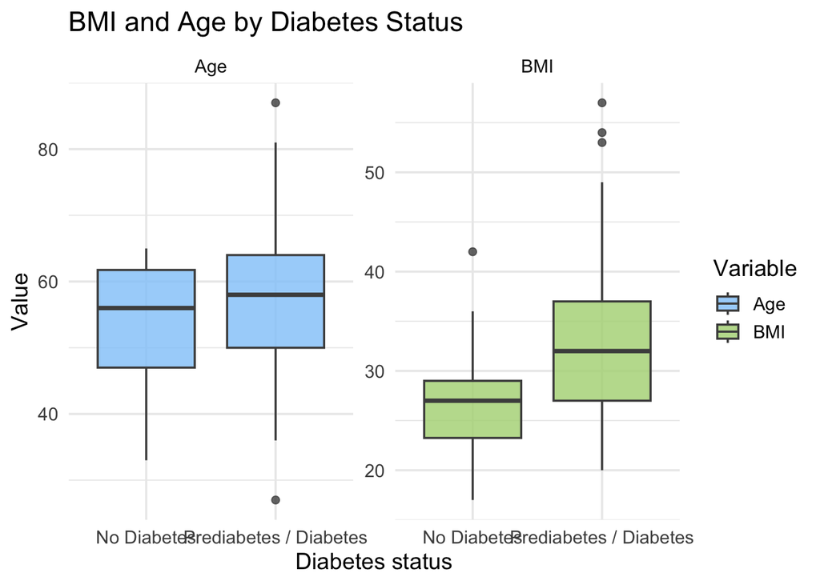

Figure 11: BMI and Age by diabetes status

```r
Q2_long <- Q2_Data %>%
  pivot_longer(cols = c(BMI, Age), names_to = "Variable", values_to = "Value")

ggplot(Q2_long, aes(x = factor(Diabetes), y = Value, fill = Variable)) +
  geom_boxplot(colour = "grey30", alpha = 0.8) +
  facet_wrap(~ Variable, scales = "free_y") +
  labs(x = "Diabetes status", y = "Value",
       title = "BMI and Age by Diabetes Status") +
  scale_x_discrete(labels = c("0" = "No Diabetes",
                               "1" = "Prediabetes / Diabetes")) +
  scale_fill_manual(values = c("BMI" = "#AED581", "Age" = "#90CAF9")) +
  theme_minimal(base_size = 14)
```

Individuals with diabetes exhibit higher mean and median BMI and Age (Table 6), with BMI showing the larger difference between groups (Figure 11). These patterns are consistent with established risk factors for diabetes. Greater variability is also observed among individuals with diabetes.

## 2.3 Initial Model Specification

$$\text{logit}(p) = \beta_0 + \beta_1
\cdot \text{HighBP} + \beta_2 \cdot \text{HighChol} + \beta_3 \cdot
\text{BMI} + \beta_4 \cdot \text{Smoker} + \beta_5 \cdot \text{Fruits} +
\beta_6 \cdot \text{Age}$$

A logistic regression model is used because the response variable is binary, and this model directly estimates the log-odds, ensuring predicted probabilities lie between 0 and 1.

```r
model <- glm(Diabetes ~ ., data = Q2_Data, family = binomial(logit))
summary(model)
```

```
##
## Call:
## glm(formula = Diabetes ~ ., family = binomial(logit), data = Q2_Data)
##
## Coefficients:
##             Estimate Std. Error z value Pr(>|z|)
## (Intercept) -8.37197    1.72001  -4.867 1.13e-06 ***
## HighBP1      0.20372    0.42341   0.481  0.63042
## HighChol1    0.80864    0.41709   1.939  0.05253 .
## BMI          0.14876    0.03626   4.102 4.09e-05 ***
## Smoker1      0.73174    0.39443   1.855  0.06357 .
## Fruits1      0.12181    0.39269   0.310  0.75642
## Age          0.05453    0.02084   2.617  0.00888 **
## ---
## Signif. codes:  0 '***' 0.001 '**' 0.01 '*' 0.05 '.' 0.1 ' ' 1
##
## (Dispersion parameter for binomial family taken to be 1)
##
##     Null deviance: 207.92  on 149  degrees of freedom
## Residual deviance: 160.69  on 143  degrees of freedom
## AIC: 174.69
##
## Number of Fisher Scoring iterations: 4
```

## 2.4 Model Selection and Refinement

### 2.4.1 G-Statistic: Overall Significance

Using the G-statistic, we assess whether the variables collectively contribute to explaining the logit. The G-statistic is calculated as the difference in deviances between the null model and the fitted model.

Hypotheses:

- $H_0: \beta_i = 0$ for all $i$
- $H_1:$ at least one $\beta_i \neq 0$

```r
G_calc <- model$null.deviance - model$deviance
Gdf    <- model$df.null - model$df.residual

G_calc
```

```
## [1] 47.22726
```

```r
qchisq(0.95, df = Gdf)
```

```
## [1] 12.59159
```

```r
1 - pchisq(G_calc, Gdf)
```

```
## [1] 1.68565e-08
```

Since G<sub>calc</sub> = 47.23 > G<sub>crit</sub> = 12.59, we reject H₀ (p-value < 0.05). The variables collectively have explanatory power.

### 2.4.2 Removing Fruits

```r
# Remove Fruits: largest p-value and z-value < 2
model_2.1 <- update(model, ~ . - Fruits, data = Q2_Data)
summary(model_2.1)
```

```
##
## Call:
## glm(formula = Diabetes ~ HighBP + HighChol + BMI + Smoker + Age,
##     family = binomial(logit), data = Q2_Data)
##
## Coefficients:
##             Estimate Std. Error z value Pr(>|z|)
## (Intercept) -8.28255    1.68958  -4.902 9.48e-07 ***
## HighBP1      0.21340    0.42275   0.505  0.61370
## HighChol1    0.80826    0.41717   1.937  0.05269 .
## BMI          0.14828    0.03612   4.105 4.04e-05 ***
## Smoker1      0.73281    0.39465   1.857  0.06334 .
## Age          0.05435    0.02081   2.611  0.00902 **
## ---
## Signif. codes:  0 '***' 0.001 '**' 0.01 '*' 0.05 '.' 0.1 ' ' 1
##
## (Dispersion parameter for binomial family taken to be 1)
##
##     Null deviance: 207.92  on 149  degrees of freedom
## Residual deviance: 160.79  on 144  degrees of freedom
## AIC: 172.79
##
## Number of Fisher Scoring iterations: 4
```

The AIC decreases from 174.69 to 172.79 (lower AIC indicates a more parsimonious model), confirming Fruits can be safely removed.

### 2.4.3 Likelihood Ratio Test for Remaining Predictors

```r
anova(model_2.1, test = "Chisq")
```

```
## Analysis of Deviance Table
##
## Model: binomial, link: logit
##
## Response: Diabetes
##
## Terms added sequentially (first to last)
##
##
##          Df Deviance Resid. Df Resid. Dev  Pr(>Chi)
## NULL                       149     207.92
## HighBP    1   7.9165       148     200.00  0.004899 **
## HighChol  1   6.8361       147     193.16  0.008933 **
## BMI       1  21.8412       146     171.32 2.962e-06 ***
## Smoker    1   2.8817       145     168.44  0.089592 .
## Age       1   7.6555       144     160.79  0.005660 **
## ---
## Signif. codes:  0 '***' 0.001 '**' 0.01 '*' 0.05 '.' 0.1 ' ' 1
```

### 2.4.4 Testing Smoker Retention

```r
# Compare model with and without Smoker
model_2.2 <- glm(Diabetes ~ HighBP + HighChol + BMI + Age,
                  family = binomial(logit), data = Q2_Data)

anova(model_2.1, model_2.2, test = "Chisq")
```

```
## Analysis of Deviance Table
##
## Model 1: Diabetes ~ HighBP + HighChol + BMI + Smoker + Age
## Model 2: Diabetes ~ HighBP + HighChol + BMI + Age
##   Resid. Df Resid. Dev Df Deviance Pr(>Chi)
## 1       144     160.79
## 2       145     164.33 -1  -3.5414  0.05985 .
## ---
## Signif. codes:  0 '***' 0.001 '**' 0.01 '*' 0.05 '.' 0.1 ' ' 1
```

Removing Smoker increases residual deviance by 3.54 on 1 df (p = 0.060), indicating marginal deterioration. Although not significant at 5%, Smoker is retained due to strong theoretical and empirical evidence that smoking increases the risk of diabetes.

## 2.5 Final Model and Interpretation

$$\text{logit}(p) = \beta_0 + \beta_1
\cdot \text{HighBP} + \beta_2 \cdot \text{HighChol} + \beta_3 \cdot
\text{BMI} + \beta_4 \cdot \text{Smoker} + \beta_5 \cdot
\text{Age}$$

```r
summary(model_2.1)
```

```
##
## Call:
## glm(formula = Diabetes ~ HighBP + HighChol + BMI + Smoker + Age,
##     family = binomial(logit), data = Q2_Data)
##
## Coefficients:
##             Estimate Std. Error z value Pr(>|z|)
## (Intercept) -8.28255    1.68958  -4.902 9.48e-07 ***
## HighBP1      0.21340    0.42275   0.505  0.61370
## HighChol1    0.80826    0.41717   1.937  0.05269 .
## BMI          0.14828    0.03612   4.105 4.04e-05 ***
## Smoker1      0.73281    0.39465   1.857  0.06334 .
## Age          0.05435    0.02081   2.611  0.00902 **
## ---
## Signif. codes:  0 '***' 0.001 '**' 0.01 '*' 0.05 '.' 0.1 ' ' 1
##
## (Dispersion parameter for binomial family taken to be 1)
##
##     Null deviance: 207.92  on 149  degrees of freedom
## Residual deviance: 160.79  on 144  degrees of freedom
## AIC: 172.79
##
## Number of Fisher Scoring iterations: 4
```

```r
# Exponentiating coefficients to obtain odds ratios
round(exp(coef(model_2.1)), 2)
```

```
## (Intercept)     HighBP1   HighChol1         BMI     Smoker1         Age
##        0.00        1.24        2.24        1.16        2.08        1.06
```

High cholesterol is associated with 2.24 times higher odds of diabetes (a 124% increase). High blood pressure is also associated with increased odds relative to those without it. Each one-unit increase in BMI increases the odds by approximately 16%, and each additional year of age increases the odds of diabetes by 6%, holding other variables constant.

## 2.6 Accuracy and Model Performance

```r
# Predicted probabilities from the final model
predprob <- predict(model_2.1, type = "response")
head(predprob)
```

```
##         1         2         3         4         5         6
## 0.8064084 0.5985937 0.2113021 0.1806493 0.3933024 0.9686627
```

```r
summary(predprob)
```

```
##    Min. 1st Qu.  Median    Mean 3rd Qu.    Max.
## 0.02757 0.28871 0.49547 0.50667 0.72623 0.96866
```

```r
# Classification rule: p >= 0.5 classified as diabetes/prediabetes
pred.diabetes <- ifelse(predprob >= 0.5, 1, 0)
actual        <- as.integer(as.character(Q2_Data$Diabetes))

confusion_matrix <- table(Predicted = pred.diabetes, Actual = actual)
confusion_matrix
```

```
##          Actual
## Predicted  0  1
##         0 53 24
##         1 21 52
```

*Table 10: Confusion matrix.*

```r
# Performance metrics
TP <- confusion_matrix["1", "1"]
TN <- confusion_matrix["0", "0"]
FP <- confusion_matrix["1", "0"]
FN <- confusion_matrix["0", "1"]

accuracy    <- sum(diag(confusion_matrix)) / sum(confusion_matrix)
sensitivity <- TP / (TP + FN)
specificity <- TN / (TN + FP)

round(c(accuracy = accuracy, sensitivity = sensitivity, specificity = specificity), 3)
```

```
##    accuracy sensitivity specificity
##       0.700       0.684       0.716
```

The model achieved an overall accuracy of 70%, which represents an improvement over the baseline accuracy of 51% (if predicting the majority class throughout). Sensitivity of 68.4% means the model correctly identifies individuals with diabetes or prediabetes in that proportion of cases. Specificity of 71.6% indicates slightly stronger performance in identifying non-diabetic individuals. The confusion matrix shows slightly more false negatives than false positives, meaning some individuals with diabetes are misclassified as non-diabetic.

**Note on overfitting:** Model performance is evaluated on the same dataset used for estimation, as the sample is small (n = 150). The reported accuracy may therefore be optimistic, and predictive performance on new data could be lower.